# Фенология копепод

Вадим Хайтов

12 марта 2019 г

## Фенологические таблицы

Для описания сезонных процессов в популяциях копепод были составлены фенологические матрицы. Колонками в этих матрицах были ключевые события в годичном цикле:

- Начало появления в толще воды копеподитов (определялось как 15% от значения асимптоты в логистической кривой, описывающей кумуляту численности)
- Конец пребывания копеподитов в толще воды (определялось как 85% от значения асимптоты в логистической кривой, описывающей кумуляту численности).
- Середина пребывания копеподитов в толще воды (определялось как точка перегиба логистической кривой)
- Пик численности копеподитов (определялось как максимальная численность за весь период наблюдений в данном году)

Строками этой матрицы были годы наблюдений.

В ячейках матрицы находились даты, когда происходило соответствующее событие (число дней, прошедших с 1-го января соответствующего года).

## Фенологическая структура сообщества копепод

Приведенный ниже рисунок показывает, что время основных событий явно расходится у разных видов

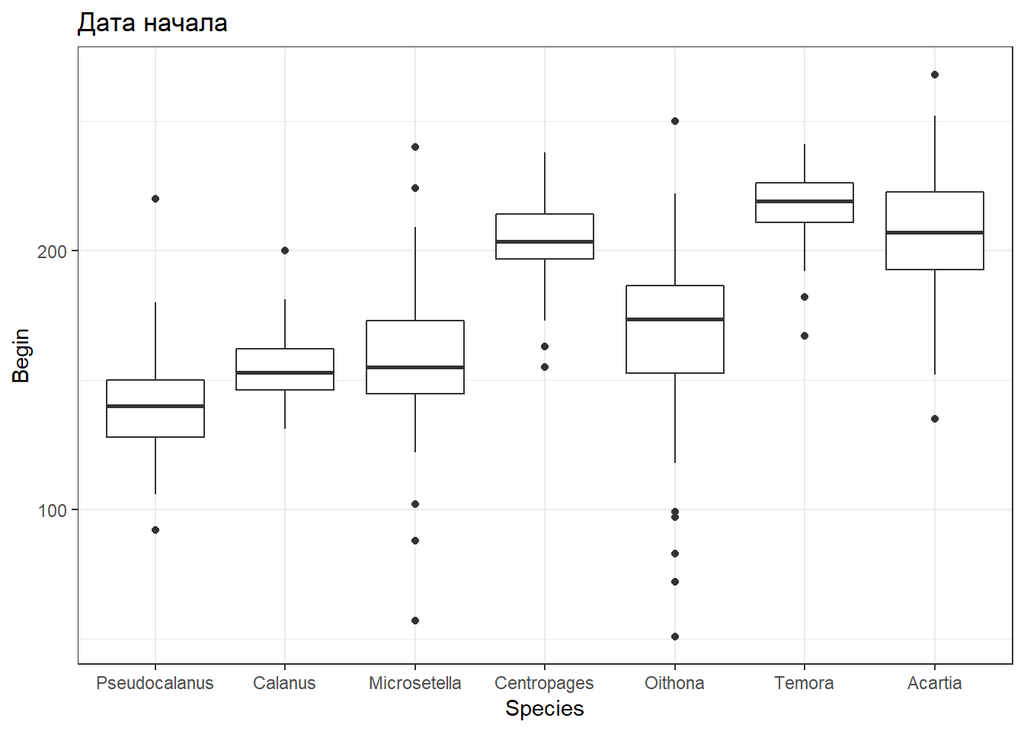

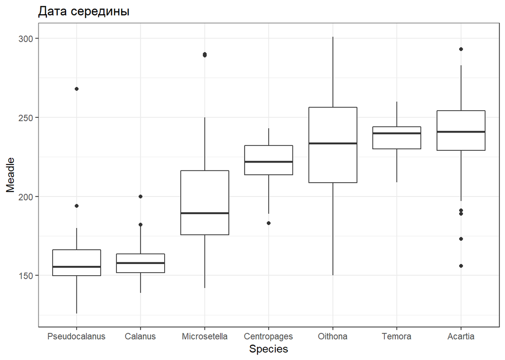

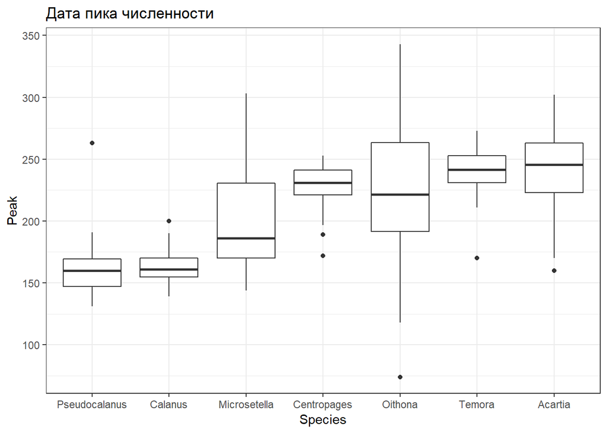

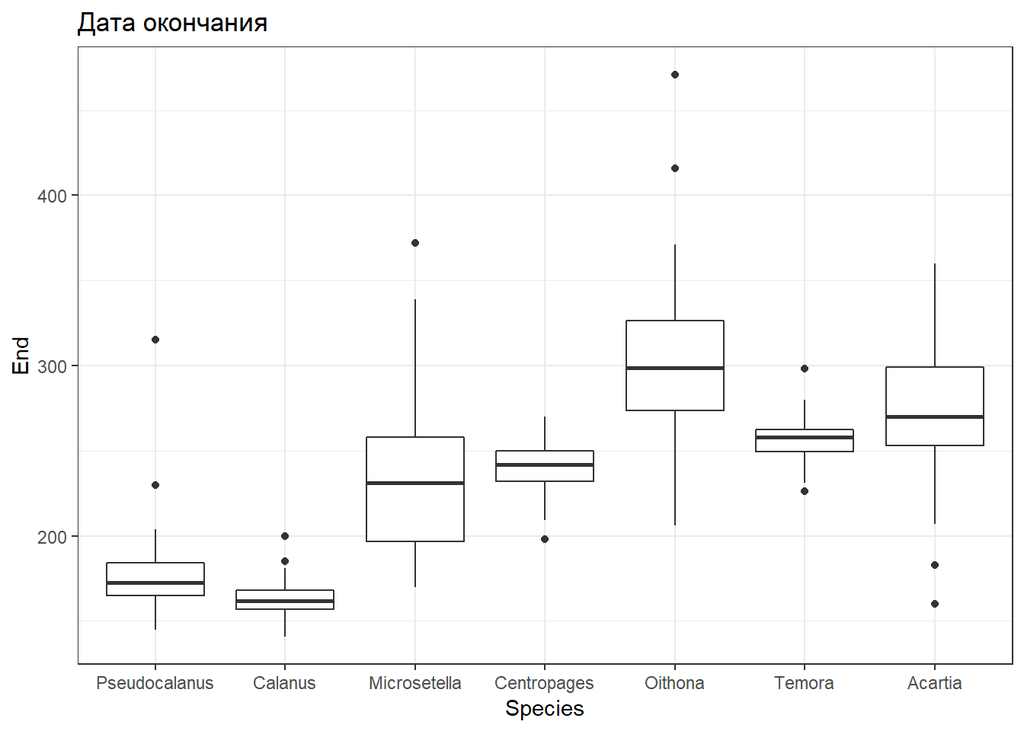

## Многолетние изменения фенологических показателей

Общий ход изменений демонстрирует следующие рисунки.

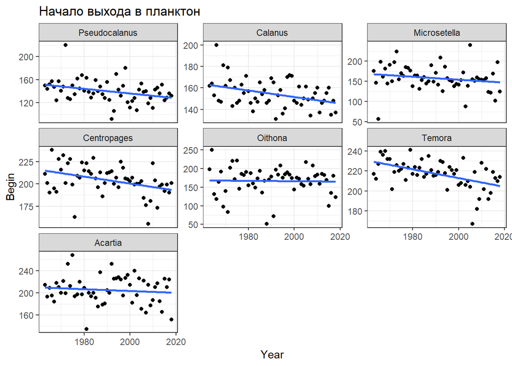

## Парамтеры линейных моделей

Но! Не надо использовать уровни значимости! Можно корректно использоввать только коэффициенты (колонка “estimate”). Угловой коэффициент показывает на сколько дней изменяется дата начала выхода в планктон за один год.

| Species | term | estimate | std.error | statistic | p.value |
| --- | --- | --- | --- | --- | --- |
| Pseudocalanus | (Intercept) | 948.8242994 | 314.4800191 | 3.0171211 | 0.0038870 |
| Pseudocalanus | Year | -0.4062884 | 0.1579853 | -2.5716859 | 0.0129061 |
| Calanus | (Intercept) | 760.1607164 | 200.4928585 | 3.7914603 | 0.0003796 |
| Calanus | Year | -0.3043081 | 0.1007216 | -3.0212813 | 0.0038417 |
| Microsetella | (Intercept) | 883.8020506 | 495.4598591 | 1.7838015 | 0.0800754 |
| Microsetella | Year | -0.3646958 | 0.2489041 | -1.4652065 | 0.1486631 |
| Centropages | (Intercept) | 983.3358510 | 252.1140145 | 3.9003617 | 0.0002680 |
| Centropages | Year | -0.3914559 | 0.1266545 | -3.0907393 | 0.0031546 |
| Oithona | (Intercept) | 269.0139781 | 622.7407055 | 0.4319839 | 0.6674732 |
| Oithona | Year | -0.0513671 | 0.3128461 | -0.1641927 | 0.8701925 |
| Temora | (Intercept) | 1093.4296992 | 201.6858375 | 5.4214501 | 0.0000014 |
| Temora | Year | -0.4402256 | 0.1013209 | -4.3448657 | 0.0000619 |
| Acartia | (Intercept) | 526.9086124 | 411.1563209 | 1.2815287 | 0.2054837 |
| Acartia | Year | -0.1617225 | 0.2065525 | -0.7829607 | 0.4370706 |

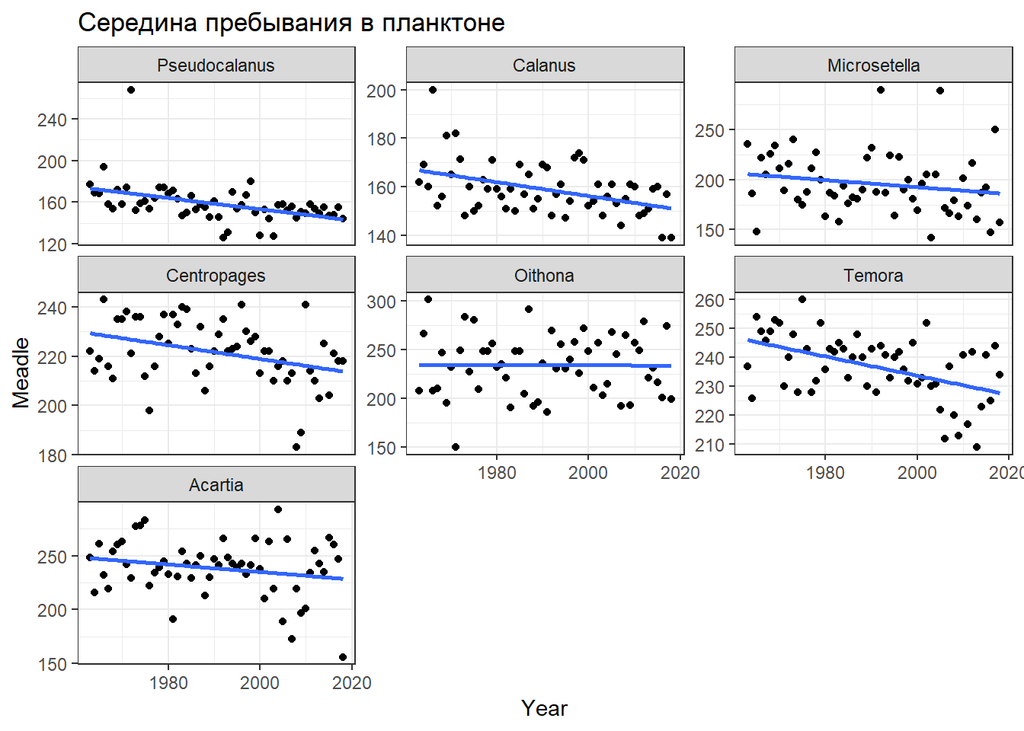

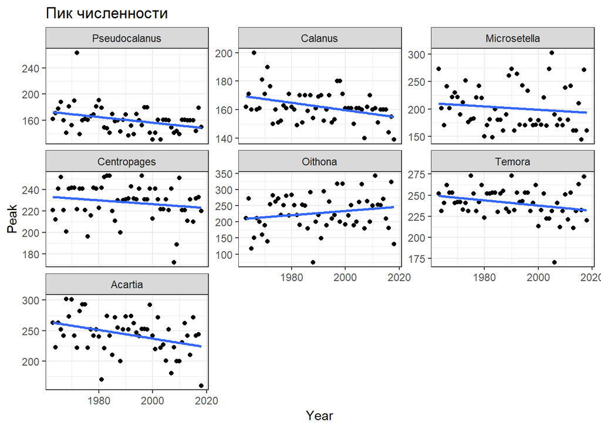

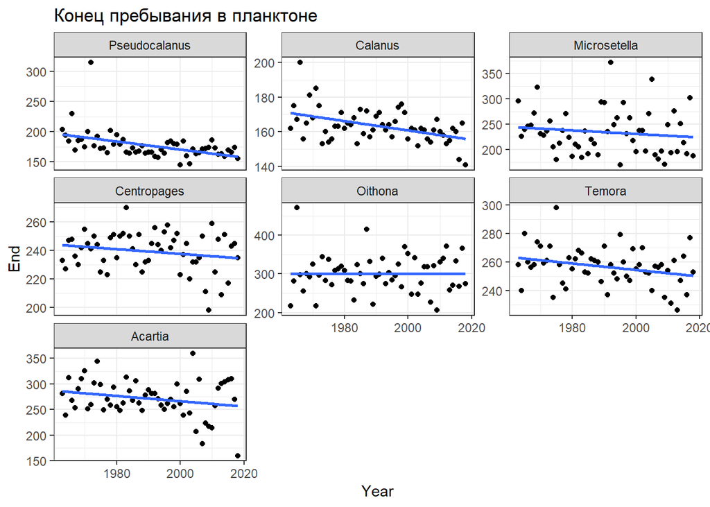

### Оценка статистической значимости тенденций

Поскольку анализ многолетних изменений фенологических показателей связан с временными автокорреляциями, то применение обычного регрессионного анализа потребует многочисленных ухищрений (если не лень, то можем сделать). Поэтому применим более простой способ оценки статистической значимости тенденций многолетних изменений. Нас интересует именно линейная составляющая (убывает или возрастает дата события в целом). То есть присутствует временной градиент. Метод основан на модельных матрицах.

Суть метода очень проста.

1. Создаем градиентную модельную матрицу, как матрицу евклидовых расстояний между численными обозначениями годов наблюдений: 1961, 1962, 1963 … 2018 -> Euclidean distance.
2. Сравниваем фенологические модельные матрицы с градиентной модельной матрицей с помощью теста Мантела.

Для начала посмотрим на общую тенденцию.

| Group | p_level |
| --- | --- |
| Total | 0.0043 |
| Acartia | 0.0381 |
| Calanus | 0.0078 |
| Centropages | 0.0457 |
| Microsetella | 0.1424 |
| Oithona | 0.0787 |
| Pseudocalanus | 0.1041 |
| Temora | 0.0018 |

## Факторы, определяющие сдвиги в фенологии сообщества копепод

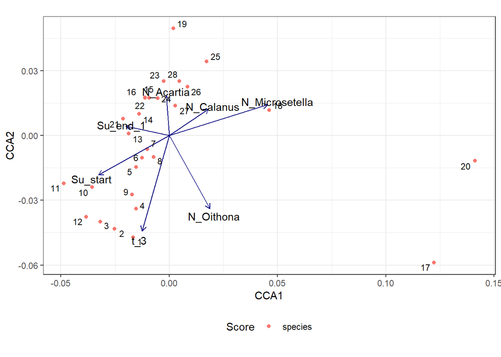

Обозначения фенологических характеристик приведены в следующей таблице.

| Phenological Event | Label | Phenological Event | Label |
| --- | --- | --- | --- |
| Pseudocalanus_Begin | 1 | Centropages_End | 15 |
| Pseudocalanus_Meadle | 2 | Centropages_Peak | 16 |
| Pseudocalanus_End | 3 | Oithona_Begin | 17 |
| Pseudocalanus_Peak | 4 | Oithona_Meadle | 18 |
| Calanus_Begin | 5 | Oithona_End | 19 |
| Calanus_Meadle | 6 | Oithona_Peak | 20 |
| Calanus_End | 7 | Temora_Begin | 21 |
| Calanus_Peak | 8 | Temora_Meadle | 22 |
| Microsetella_Begin | 9 | Temora_End | 23 |
| Microsetella_Meadle | 10 | Temora_Peak | 24 |
| Microsetella_End | 11 | Acartia_Begin | 25 |
| Microsetella_Peak | 12 | Acartia_Meadle | 26 |
| Centropages_Begin | 13 | Acartia_End | 27 |
| Centropages_Meadle | 14 | Acartia_Peak | 28 |

## Что это означает?

### 1. Информативность ординации

Полученная модель (при учете всех канонических корреспондентных осей) объясняет 26.5% суммарной изменчивости. При этом на первую и вторую оси приходится 12.5 и 5.5% соответственно (то есть приведенная на рисунке ординация отражает 18.1% общей изменчивости.

### 2. Значимость ординации в целом

```
## Permutation test for cca under reduced model
## Permutation: free
## Number of permutations: 9999
##
## Model: cca(formula = phenol[, -1] ~ t_3 + Su_start + Su_end_1 + N_Acartia + N_Calanus + N_Microsetella + N_Oithona, data = env_abund)
##          Df ChiSquare      F Pr(>F)
## Model     7 0.0034804 2.4771  1e-04 ***
## Residual 48 0.0096345
## ---
## Signif. codes:  0 '***' 0.001 '**' 0.01 '*' 0.05 '.' 0.1 ' ' 1
```

3. Значимость осей

```
## Permutation test for cca under reduced model
## Forward tests for axes
## Permutation: free
## Number of permutations: 9999
##
## Model: cca(formula = phenol[, -1] ~ t_3 + Su_start + Su_end_1 + N_Acartia + N_Calanus + N_Microsetella + N_Oithona, data = env_abund)
##          Df ChiSquare      F Pr(>F)
## CCA1      1 0.0016409 8.1754 0.0002 ***
## CCA2      1 0.0007272 3.6229 0.1240
## CCA3      1 0.0005874 2.9265 0.2058
## CCA4      1 0.0002324 1.1579 0.9493
## CCA5      1 0.0001431 0.7129 0.9905
## CCA6      1 0.0001095 0.5455 0.9840
## CCA7      1 0.0000399 0.1987 0.9973
## Residual 48 0.0096345
## ---
## Signif. codes:  0 '***' 0.001 '**' 0.01 '*' 0.05 '.' 0.1 ' ' 1
```

### 4. Значимоть отдельных предикторов

```
## Permutation test for cca under reduced model
## Marginal effects of terms
## Permutation: free
## Number of permutations: 9999
##
## Model: cca(formula = phenol[, -1] ~ t_3 + Su_start + Su_end_1 + N_Acartia + N_Calanus + N_Microsetella + N_Oithona, data = env_abund)
##                Df ChiSquare      F Pr(>F)
## t_3             1 0.0003905 1.9453 0.0540 .
## Su_start        1 0.0004639 2.3111 0.0251 *
## Su_end_1        1 0.0005848 2.9137 0.0075 **
## N_Acartia       1 0.0004616 2.2999 0.0279 *
## N_Calanus       1 0.0004559 2.2714 0.0240 *
## N_Microsetella  1 0.0009154 4.5608 0.0004 ***
## N_Oithona       1 0.0003885 1.9354 0.0584 .
## Residual       48 0.0096345
## ---
## Signif. codes:  0 '***' 0.001 '**' 0.01 '*' 0.05 '.' 0.1 ' ' 1
```

## Многолетняя динамика обилия видов

Действительно, снижение Oithona просходит на фоне роста обилия Microsetella. Учитывая, что фенология Oithona находится в связи с обилием Microsetella (оитона демонстрирует более поздние пики, если в данный год много микросетеллы), то можно заподозрить конкуренцию.

Итерсесно, что у акартии?

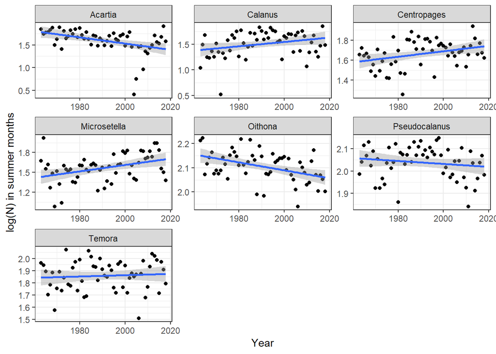

## Мнолетние изенения даты наступления лета и весны

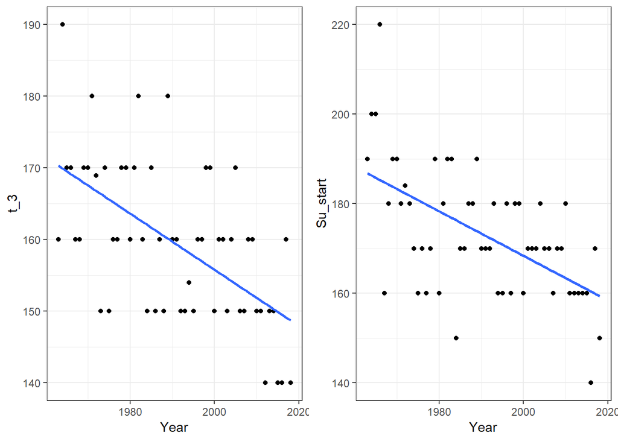

А вот парамтеры лнейны моделей для них.

Для начала весны

```
##
## Call:
## lm(formula = t_3 ~ Year, data = env_abund)
##
## Residuals:
##      Min       1Q   Median       3Q      Max
## -16.3831  -7.8991  -0.4911   5.6294  20.0854
##
## Coefficients:
##             Estimate Std. Error t value Pr(>|t|)
## (Intercept) 940.5776   147.6994   6.368 4.36e-08 ***
## Year         -0.3924     0.0742  -5.288 2.29e-06 ***
## ---
## Signif. codes:  0 '***' 0.001 '**' 0.01 '*' 0.05 '.' 0.1 ' ' 1
##
## Residual standard error: 8.975 on 54 degrees of freedom
## Multiple R-squared:  0.3412, Adjusted R-squared:  0.329
## F-statistic: 27.97 on 1 and 54 DF,  p-value: 2.29e-06
```

Для начала лета.

```
##
## Call:
## lm(formula = Su_start ~ Year, data = env_abund)
##
## Residuals:
##     Min      1Q  Median      3Q     Max
## -26.342  -6.479   0.406   7.053  34.701
##
## Coefficients:
##              Estimate Std. Error t value Pr(>|t|)
## (Intercept) 1163.5661   193.0928   6.026 1.55e-07 ***
## Year          -0.4976     0.0970  -5.130 4.04e-06 ***
## ---
## Signif. codes:  0 '***' 0.001 '**' 0.01 '*' 0.05 '.' 0.1 ' ' 1
##
## Residual standard error: 11.73 on 54 degrees of freedom
## Multiple R-squared:  0.3276, Adjusted R-squared:  0.3152
## F-statistic: 26.31 on 1 and 54 DF,  p-value: 4.044e-06
```

## Картинка для тезисов

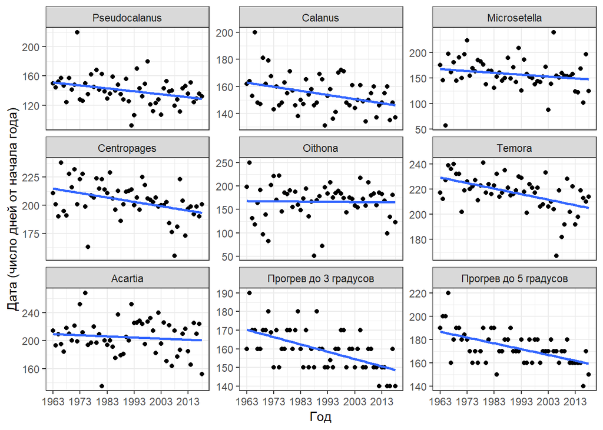